# Importing Necessary Libraries and Data

```python
import pandas as pd
import numpy as np
import matplotlib.pyplot as plt
import seaborn as sns
from sklearn.model_selection import train_test_split
from sklearn.preprocessing import LabelEncoder, StandardScaler
from sklearn.ensemble import RandomForestClassifier
from sklearn.tree import DecisionTreeClassifier
from sklearn.metrics import classification_report, confusion_matrix, accuracy_score
import warnings
warnings.filterwarnings("ignore", category=FutureWarning)
```

# Load the Data

```python
data = pd.read_csv('/content/ExtraaLearn (1).csv')
```

Checking the Dataset

```python
print(data.head())
```

```
       ID  age current_occupation first_interaction profile_completed  \
0  EXT001   57         Unemployed           Website              High
1  EXT002   56       Professional        Mobile App            Medium
2  EXT003   52       Professional           Website            Medium
3  EXT004   53         Unemployed           Website              High
4  EXT005   23            Student           Website              High

   website_visits  time_spent_on_website  page_views_per_visit  \
0               7                   1639                 1.861
1               2                     83                 0.320
2               3                    330                 0.074
3               4                    464                 2.057
4               4                    600                16.914

      last_activity print_media_type1 print_media_type2 digital_media  \
0  Website Activity               Yes                No           Yes
1  Website Activity                No                No            No
2  Website Activity                No                No           Yes
3  Website Activity                No                No            No
4    Email Activity                No                No            No

  educational_channels referral  status
0                   No       No       1
1                  Yes       No       0
2                   No       No       0
3                   No       No       1
4                   No       No       0
```

# Observation

1. Shape of the Dataset
2. Column Names
3. Data Types

```python
print("Shape of the dataset: ", data.shape)
```

```
Shape of the dataset:  (4612, 15)
```

```python
print("\nColumn names:\n", data.dtypes)
```

```
Column names:
 ID                        object
age                        int64
current_occupation        object
first_interaction         object
profile_completed         object
website_visits             int64
time_spent_on_website      int64
page_views_per_visit     float64
last_activity             object
print_media_type1         object
print_media_type2         object
digital_media             object
educational_channels      object
referral                  object
status                     int64
dtype: object
```

```python
print("\ndata types:\n", data.dtypes)
```

```
data types:
 ID                        object
age                        int64
current_occupation        object
first_interaction         object
profile_completed         object
website_visits             int64
time_spent_on_website      int64
page_views_per_visit     float64
last_activity             object
print_media_type1         object
print_media_type2         object
digital_media             object
educational_channels      object
referral                  object
status                     int64
dtype: object
```

# Sanity Checking

1. Duplicate Roww Verification
2. Valid Range Checking for Age
3. Outlier Detection via Boxplot
4. distribution of website visits and page views per visit

```python
duplicate_rows = data.duplicated().sum()
print("\nNumber of duplicate rows: ", duplicate_rows)
```

```
Number of duplicate rows:  0
```

```python
invalid_age = data[(data['age'] < 18) | (data['age'] > 63)]
if not invalid_age.empty:
    print("\nInvalid age entries:\n", invalid_age)
else:
    print("\nAll age values are within valid range.")
```

```
All age values are within valid range.
```

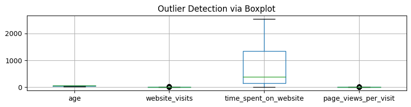

```python
numerical_columns = ['age', 'website_visits', 'time_spent_on_website', 'page_views_per_visit']
plt.figure(figsize=(10, 2))
data[numerical_columns].boxplot()
plt.title("Outlier Detection via Boxplot")
plt.show()
```

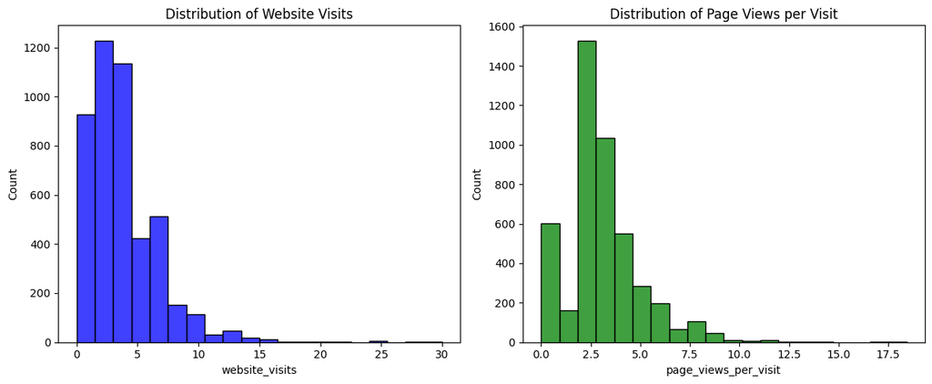

```python
plt.figure(figsize=(12, 5))
plt.subplot(1, 2, 1)
sns.histplot(data['website_visits'], kde=False, bins=20, color='blue')
plt.title('Distribution of Website Visits')
plt.subplot(1, 2, 2)
sns.histplot(data['page_views_per_visit'], kde=False, bins=20, color='green')
plt.title('Distribution of Page Views per Visit')
plt.tight_layout()
plt.show()
```

# Univariate Analysis

1. Age Distribution
2. Distribution of Profile Completion
3. Distribution of Current Occupation

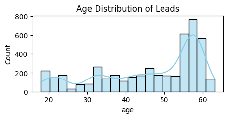

```python
plt.figure(figsize=(5, 2))
sns.histplot(data['age'], bins=20, kde=True, color='skyblue')
plt.title("Age Distribution of Leads")
plt.show()
```

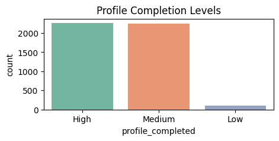

```python
plt.figure(figsize=(5, 2))
sns.countplot(x='profile_completed', hue='profile_completed', data=data, palette='Set2', dodge=False)
plt.title("Profile Completion Levels")
plt.legend([], [], frameon=False)  # Removing legend since it's redundant
plt.show()
```

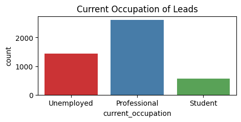

```python
plt.figure(figsize=(5, 2))
sns.countplot(x='current_occupation', hue='current_occupation', data=data, palette='Set1', dodge=False)
plt.title("Current Occupation of Leads")
plt.legend([], [], frameon=False)
plt.show()
```

# Bivariate Analysis

1. Conversion rate by Current Occupattion
2. Conversion Rate by Profile Completion

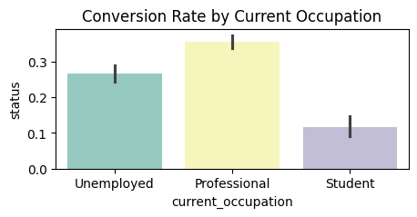

```python
plt.figure(figsize=(5, 2))
sns.barplot(x='current_occupation', y='status', data=data, palette='Set3')
plt.title("Conversion Rate by Current Occupation")
plt.show()
```

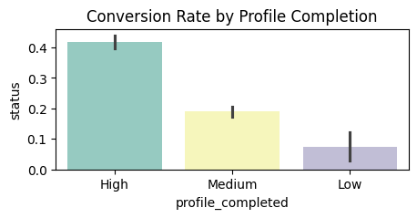

```python
plt.figure(figsize=(5, 2))
sns.barplot(x='profile_completed', y='status', data=data, palette='Set3')
plt.title("Conversion Rate by Profile Completion")
plt.show()
```

# Analyzing behavior-related features

1. Website Visits vs Conversion
2. Page Views Per Visit vs Conversion

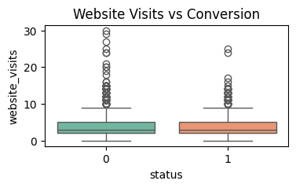

```python
plt.figure(figsize=(4, 2))
sns.boxplot(x='status', y='website_visits', data=data, palette='Set2')
plt.title("Website Visits vs Conversion")
plt.show()
```

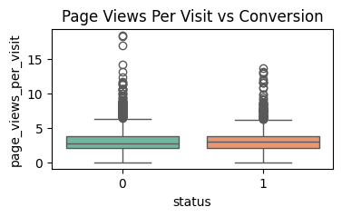

```python
plt.figure(figsize=(4, 2))
sns.boxplot(x='status', y='page_views_per_visit', data=data, palette='Set2')
plt.title("Page Views Per Visit vs Conversion")
plt.show()
```

# Correlation Analysis

1. Correlation heatmap for numerical features

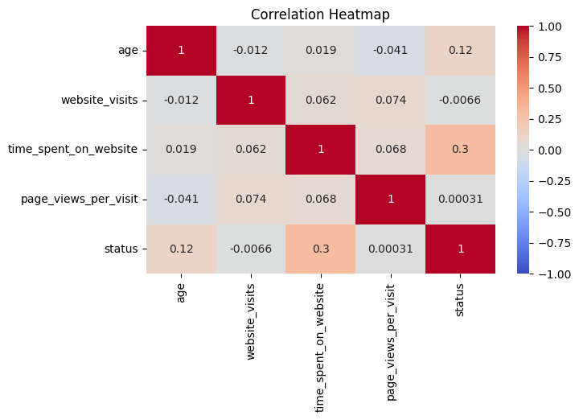

```python
plt.figure(figsize=(7, 4))
corr = data[['age', 'website_visits', 'time_spent_on_website', 'page_views_per_visit', 'status']].corr()
sns.heatmap(corr, annot=True, cmap='coolwarm', vmin=-1, vmax=1)
plt.title("Correlation Heatmap")
plt.show()
```

# Missing values

```python
print("\nMissing values in each column:\n", data.isnull().sum())
```

```
Missing values in each column:
 ID                       0
age                      0
current_occupation       0
first_interaction        0
profile_completed        0
website_visits           0
time_spent_on_website    0
page_views_per_visit     0
last_activity            0
print_media_type1        0
print_media_type2        0
digital_media            0
educational_channels     0
referral                 0
status                   0
dtype: int64
```

# Feature Engineering

1. Encoding categorical
2. Categorical features to encode

```python
label_encoder = LabelEncoder()
```

```python
categorical_columns = ['current_occupation', 'first_interaction', 'profile_completed', 'last_activity','print_media_type1', 'print_media_type2', 'digital_media', 'educational_channels', 'referral']
for col in categorical_columns:
    data[col] = label_encoder.fit_transform(data[col])
```

Data Visualization

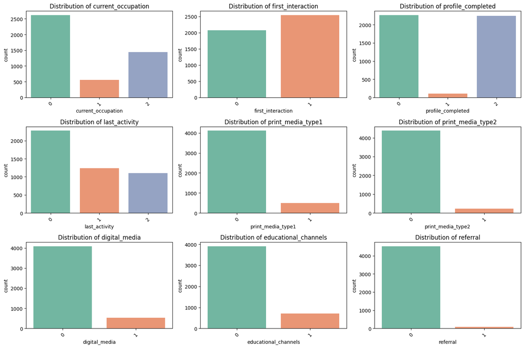

```python
plt.figure(figsize=(15, 10))
for i, col in enumerate(categorical_columns, 1):
    plt.subplot(3, 3, i)
    sns.countplot(x=col, data=data, palette='Set2')
    plt.title(f'Distribution of {col}')
    plt.xticks(rotation=45)
plt.tight_layout()
plt.show()
```

# Outlier Detection

1. Detect outliers using boxplots for numerical columns

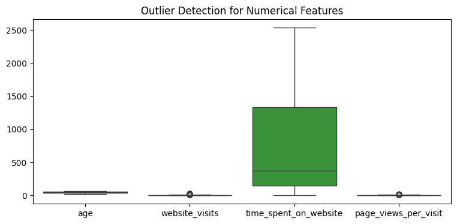

```python
numerical_columns = ['age', 'website_visits', 'time_spent_on_website', 'page_views_per_visit']

plt.figure(figsize=(9, 4))
sns.boxplot(data=data[numerical_columns])
plt.title("Outlier Detection for Numerical Features")
plt.show()
```

# Preparing Model Data

1. Describing X and Y
2. Scaling

```python
X = data.drop(columns=['ID', 'status'])
y = data['status']
```

```python
scaler = StandardScaler()
X_scaled = scaler.fit_transform(X)
```

```python
print("\nScaled Data (First 5 rows):\n", pd.DataFrame(X_scaled, columns=X.columns).head())
```

```
Scaled Data (First 5 rows):
         age  current_occupation  first_interaction  profile_completed  \
0  0.820575            1.390116           0.902396          -1.006773
1  0.744587           -0.825614          -1.108160           1.016865
2  0.440636           -0.825614           0.902396           1.016865
3  0.516624            1.390116           0.902396          -1.006773
4 -1.763007            0.282251           0.902396          -1.006773

   website_visits  time_spent_on_website  page_views_per_visit  last_activity  \
0        1.213654               1.230240             -0.592062       1.536958
1       -0.553863              -0.861866             -1.375126       1.536958
2       -0.200359              -0.529764             -1.500131       1.536958
3        0.153144              -0.349596             -0.492464       1.536958
4        0.153144              -0.166738              7.057165      -0.911557

   print_media_type1  print_media_type2  digital_media  educational_channels  \
0           2.877443           -0.23067       2.784138             -0.424789
1          -0.347531           -0.23067      -0.359178              2.354112
2          -0.347531           -0.23067       2.784138             -0.424789
3          -0.347531           -0.23067      -0.359178             -0.424789
4          -0.347531           -0.23067      -0.359178             -0.424789

   referral
0 -0.143457
1 -0.143457
2 -0.143457
3 -0.143457
4 -0.143457
```

Distribution of Numerical features

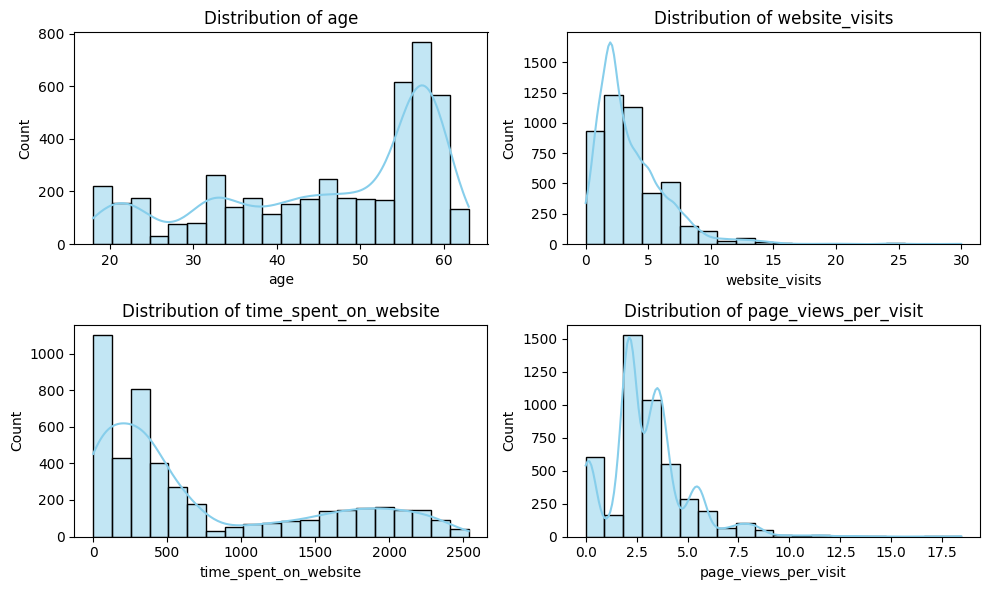

```python
numerical_columns = ['age', 'website_visits', 'time_spent_on_website', 'page_views_per_visit']
plt.figure(figsize=(10, 6))
for col in numerical_columns:
    plt.subplot(2, 2, numerical_columns.index(col) + 1)
    sns.histplot(data[col], bins=20, kde=True, color='skyblue')
    plt.title(f'Distribution of {col}')
plt.tight_layout()
plt.show()
```

# Splitting Test and Train Data

```python
X = data.drop(columns=['ID', 'status'])  # Features
y = data['status']
```

```python
X_train, X_test, y_train, y_test = train_test_split(X, y, test_size=0.2, random_state=42)
```

# Building Decision Tree Classifier Model

1.Initialization

```python
decision_tree = DecisionTreeClassifier(random_state=42)
```

2.Model Training

```python
decision_tree.fit(X_train, y_train)
```

```
DecisionTreeClassifier(random_state=42)
```

3.Prediction on Decision Tree ( Test and Train )

```python
y_train_pred = decision_tree.predict(X_train)
y_test_pred = decision_tree.predict(X_test)
```

4.Evaluation of Train Data

```python
train_accuracy = accuracy_score(y_train, y_train_pred)
print("Decision Tree - Train Accuracy:", train_accuracy)
```

```
Decision Tree - Train Accuracy: 0.9997289238275956
```

5.Evaluation of Test Data

```python
test_accuracy = accuracy_score(y_test, y_test_pred)
print("Decision Tree - Test Accuracy:", test_accuracy)
```

```
Decision Tree - Test Accuracy: 0.8266522210184182
```

6.Confusion Matrix

```python
y_pred_dt = decision_tree.predict(X_test)
conf_matrix_dt = confusion_matrix(y_test, y_pred_dt)
print("Confusion Matrix for Decision Tree:")
print(conf_matrix_dt)
```

```
Confusion Matrix for Decision Tree:
[[576  73]
 [ 87 187]]
```

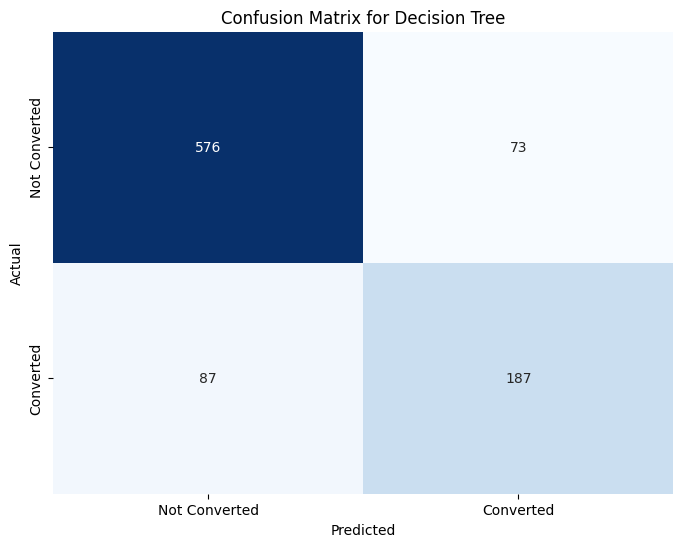

```python
plt.figure(figsize=(8, 6))
sns.heatmap(conf_matrix_dt, annot=True, fmt='d', cmap='Blues', cbar=False,
            xticklabels=['Not Converted', 'Converted'],
            yticklabels=['Not Converted', 'Converted'])
plt.title("Confusion Matrix for Decision Tree")
plt.xlabel('Predicted')
plt.ylabel('Actual')
plt.show()
```

7.Visualization of Model

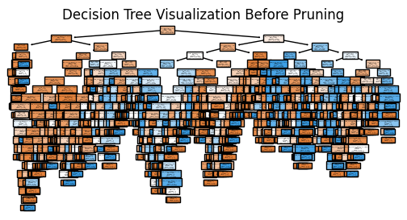

```python
from sklearn.tree import plot_tree
plt.figure(figsize=(6, 3))
plot_tree(decision_tree, filled=True, feature_names=X.columns, class_names=['Not Converted', 'Converted'])
plt.title("Decision Tree Visualization Before Pruning")
plt.show()
```

- Pruned Decision Tree Classifier Model

1.Initialization of Model

```python
pruned_tree = DecisionTreeClassifier(max_depth=5, min_samples_leaf=10, random_state=42)
```

2.Training of Pruned Model

```python
pruned_tree.fit(X_train, y_train)
```

```
DecisionTreeClassifier(max_depth=5, min_samples_leaf=10, random_state=42)
```

3.Predictions for Pruned Model

```python
y_train_pred_pruned = pruned_tree.predict(X_train)
y_test_pred_pruned = pruned_tree.predict(X_test)
```

4.Accuracy of Pruned Model

```python
train_accuracy_pruned = accuracy_score(y_train, y_train_pred_pruned)
print(f"Training accuracy of pruned Decision Tree: {train_accuracy_pruned:.2f}")
```

```
Training accuracy of pruned Decision Tree: 0.86
```

5.Accuracy for Pruned Model

```python
test_accuracy_pruned = accuracy_score(y_test, y_test_pred_pruned)
print(f"Testing accuracy of pruned Decision Tree: {test_accuracy_pruned:.2f}")
```

```
Testing accuracy of pruned Decision Tree: 0.87
```

6.Confusion Matrix

```python
y_pred_pruned_dt = pruned_tree.predict(X_test)
conf_matrix_pruned_dt = confusion_matrix(y_test, y_pred_pruned_dt)
print("Confusion Matrix for Pruned Decision Tree:")
print(conf_matrix_pruned_dt)
```

```
Confusion Matrix for Pruned Decision Tree:
[[597  52]
 [ 69 205]]
```

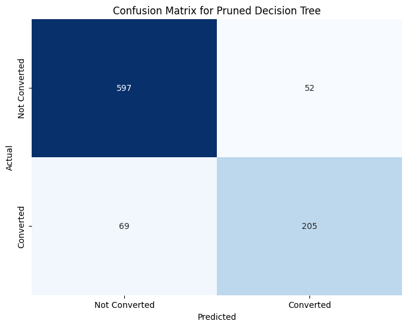

```python
plt.figure(figsize=(8, 6))
sns.heatmap(conf_matrix_pruned_dt, annot=True, fmt='d', cmap='Blues', cbar=False,xticklabels=['Not Converted', 'Converted'],yticklabels=['Not Converted', 'Converted'])
plt.title('Confusion Matrix for Pruned Decision Tree')
plt.xlabel('Predicted')
plt.ylabel('Actual')
plt.show()
```

7.Visualization for Pruned Model

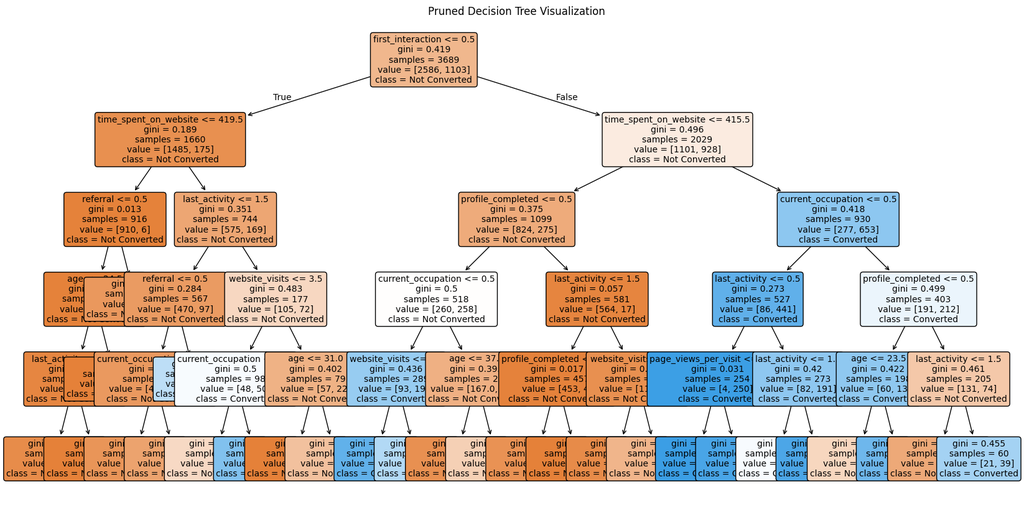

```python
plt.figure(figsize=(20,10))
plot_tree(pruned_tree,feature_names=X.columns,class_names=['Not Converted', 'Converted'],filled=True,rounded=True,proportion=False,fontsize=10)
plt.title("Pruned Decision Tree Visualization")
plt.show()
```

# Random Forest Classifier

1.Initialization of Random Forest Classifier

```python
random_forest = RandomForestClassifier(n_estimators=100, random_state=42)
```

2.Training the Model

```python
random_forest.fit(X_train, y_train)
```

```
RandomForestClassifier(random_state=42)
```

3.Prediction of Model

```python
y_train_pred = random_forest.predict(X_train)
y_test_pred = random_forest.predict(X_test)
```

4.Accuracy of Train and Test Data

```python
train_accuracy = accuracy_score(y_train, y_train_pred)
print("Random Forest - Train Accuracy:", train_accuracy)

test_accuracy = accuracy_score(y_test, y_test_pred)
print("Random Forest - Test Accuracy:", test_accuracy)
```

```
Random Forest - Train Accuracy: 0.9997289238275956
Random Forest - Test Accuracy: 0.8613217768147345
```

5.Confusion Matrix

```python
y_pred_rf = random_forest.predict(X_test)
conf_matrix_rf = confusion_matrix(y_test, y_pred_rf)
print("Confusion Matrix for Random Forest:")
print(conf_matrix_rf)
```

```
Confusion Matrix for Random Forest:
[[608  41]
 [ 87 187]]
```

```python
def plot_confusion_matrix(conf_matrix, title):
    plt.figure(figsize=(8, 6))  # Set the figure size
    sns.heatmap(conf_matrix, annot=True, fmt='d', cmap='Blues', cbar=False,
                xticklabels=['Not Converted', 'Converted'],  # Modify these labels based on your classes
                yticklabels=['Not Converted', 'Converted'])
    plt.title(title)
    plt.xlabel('Predicted')
    plt.ylabel('Actual')
    plt.show()
```

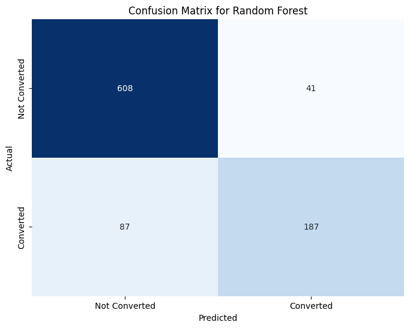

```python
plot_confusion_matrix(conf_matrix_rf, "Confusion Matrix for Random Forest")
```

6.Visualization of Model

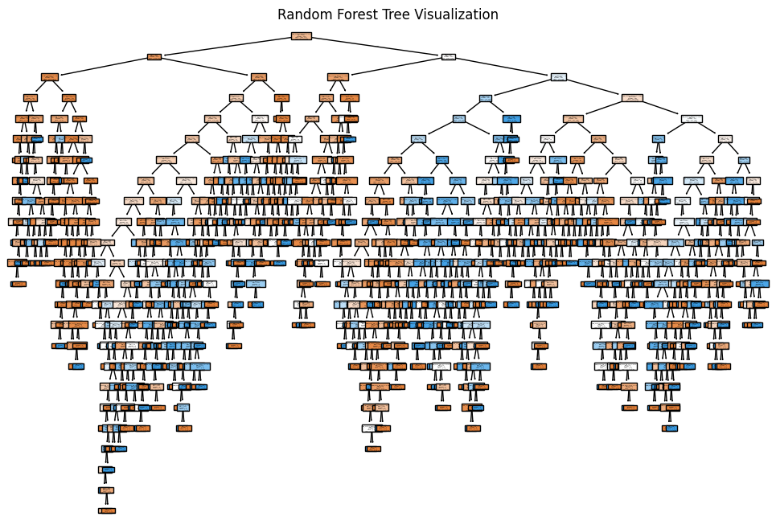

```python
plt.figure(figsize=(12, 8))
plot_tree(random_forest.estimators_[0], filled=True, feature_names=X.columns, class_names=['Not Converted', 'Converted'])
plt.title("Random Forest Tree Visualization")
plt.show()
```

- Pruned Random Forest Classifier Model

1.Initialization of Pruned Model

```python
pruned_random_forest = RandomForestClassifier(n_estimators=100, max_depth=5,min_samples_split=10,min_samples_leaf=5,max_features='sqrt',random_state=42)
```

2.Training of Random Forest Classifier Model

```python
pruned_random_forest.fit(X_train, y_train)
y_pred_pruned_rf = pruned_random_forest.predict(X_test)
```

3.Predictions of Random Forest Classifier Model

```python
y_train_pred = pruned_random_forest.predict(X_train)
y_test_pred = pruned_random_forest.predict(X_test)
```

4.Accuracy of Pruned Train and Test Data

```python
train_accuracy = accuracy_score(y_train, y_train_pred)
print("Random Forest - Train Accuracy:", train_accuracy)

test_accuracy = accuracy_score(y_test, y_test_pred)
print("Random Forest - Test Accuracy:", test_accuracy)
```

```
Random Forest - Train Accuracy: 0.8498238004879372
Random Forest - Test Accuracy: 0.8266522210184182
```

5.Confusion Matrix

```python
conf_matrix = confusion_matrix(y_test, y_test_pred)
print("Confusion Matrix for Pruned Random Forest:")
print(conf_matrix)
```

```
Confusion Matrix for Pruned Random Forest:
[[617  32]
 [128 146]]
```

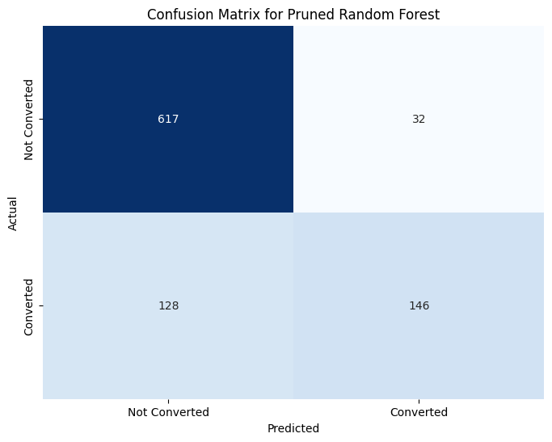

```python
plot_confusion_matrix(conf_matrix, "Confusion Matrix for Pruned Random Forest")
```